# SWCPractice

JJ

Tuesday, June 17, 2014

- Move into your working directory (the one you have been working with for git and github)
- Take a look at the file, and pick three countries you are interested in.
- select all the data for that country (hint, use the subset() function)
- use ggplot make a three scatter plots (one for each country) that has year on the x-axis and GDP on the y axis.

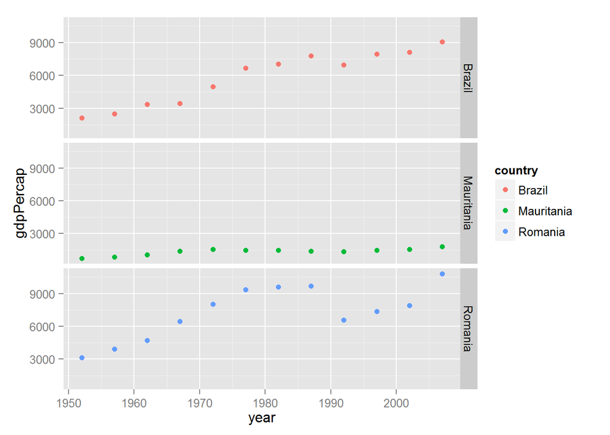

- Describe any trends you see for each country using markdown text.

- Commit your changes using git.
- Calculate the mean, min, and max life expectancies for each continent (hint: you use aggregate() if you like).

```
##   continent  mean   min   max
## 1    Africa 48.87 23.60 76.44
## 2  Americas 64.66 37.58 80.65
## 3      Asia 60.06 28.80 82.60
## 4    Europe 71.90 43.59 81.76
## 5   Oceania 74.33 69.12 81.23
```

- Describe what you see in the results using a markdown text. Africa has the lowest life expectancy. Europeand and Oceania have the highest life expectancy, but the min life expectancy in Oceania is much higher. Asia and Americas are about average.
- Commit your changes using git and push them to github.
- Make a 2 histograms of global life expectancy using ggplot.

One with the default bin widths and one with narrower bin widths (you can check in the pdf from yesterday’s lesson for the syntax you might need to do this). Explain the differences and any interesting trends in markdown text.

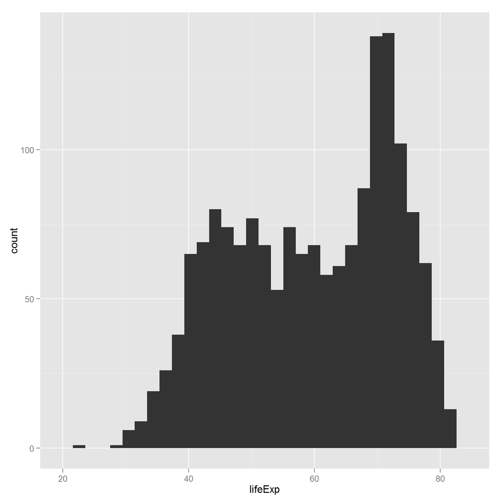

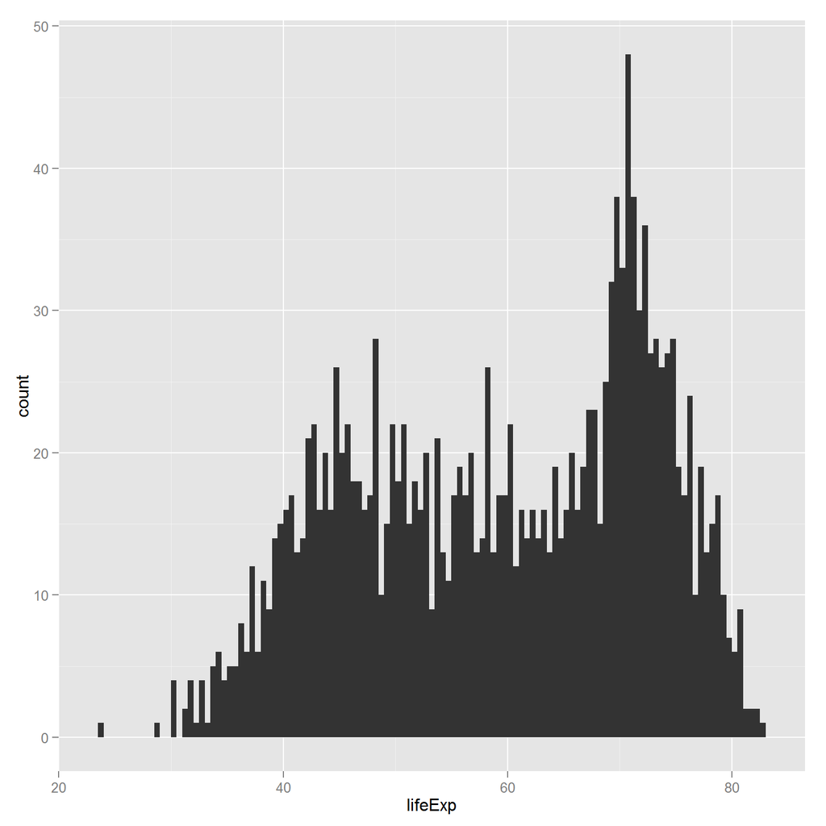

Using the default width shows more of the general pattern of life Expentacies. Using the narrower width allows us to see more detailed information.